# Final Project Tutorial: Bratz Statz

As a child I was obsessed with the Bratz, a line of fashion dolls created by MGA Entertainment. Recently, I’ve been indulging in nostalgia and trying tot see what the Bratz are up to these days, and it seems like they’re attempting to make a comeback. Now as someone who loves the Bratz, I don’t want to see them fail. So, I decided to take a look at their social media stats and see how successful their attempt at a comeback will be. To do this, I went to https://www.apify.com/ and used their Instagram and TikTok scraper to download data about every post the Bratz official account has made on these sites.

Unfortunately, this gave me way more data than I intended to work with.

```python
import pandas as pd
import matplotlib.pyplot as plt
from matplotlib.pyplot import figure
import numpy as np

tt_df = pd.read_csv("bratz tiktok.csv")
tt_df
```

|  | authorMeta/avatar | authorMeta/bioLink | authorMeta/commerceUserInfo/category | authorMeta/commerceUserInfo/categoryButton | authorMeta/commerceUserInfo/commerceUser | authorMeta/digg | authorMeta/fans | authorMeta/following | authorMeta/heart | authorMeta/id | ... | playCount | shareCount | text | videoMeta/coverUrl | videoMeta/definition | videoMeta/duration | videoMeta/format | videoMeta/height | videoMeta/width | webVideoUrl |
| --- | --- | --- | --- | --- | --- | --- | --- | --- | --- | --- | --- | --- | --- | --- | --- | --- | --- | --- | --- | --- | --- |
| 0 | https://p19-sign.tiktokcdn-us.com/tos-useast5-... | https://linktr.ee/OnlyBratzRBratz | Fashion | False | True | 368 | 2000000 | 144 | 24500000 | 6839473865820177414 | ... | 22000 | 14 | Bratz x @Velvet Caviar is officially live! Whi... | https://p16-sign.tiktokcdn-us.com/obj/tos-usea... | 720p | 18 | mp4 | 1024 | 576 | https://www.tiktok.com/@bratz/video/7174581435... |
| 1 | https://p19-sign.tiktokcdn-us.com/tos-useast5-... | https://linktr.ee/OnlyBratzRBratz | Fashion | False | True | 368 | 2000000 | 144 | 24500000 | 6839473865820177414 | ... | 10800 | 8 | Bratz x @velvetcaviar is officially live! 📲 Li... | https://p16-sign.tiktokcdn-us.com/obj/tos-usea... | 720p | 29 | mp4 | 1024 | 576 | https://www.tiktok.com/@bratz/video/7174543813... |
| 2 | https://p19-sign.tiktokcdn-us.com/tos-useast5-... | https://linktr.ee/OnlyBratzRBratz | Fashion | False | True | 368 | 2000000 | 144 | 24500000 | 6839473865820177414 | ... | 104000 | 47 | Tomorrow!! @Velvet Caviar 👄☎️ #bratz #phonecas... | https://p19-sign.tiktokcdn-us.com/obj/tos-usea... | 720p | 12 | mp4 | 1024 | 576 | https://www.tiktok.com/@bratz/video/7174190221... |
| 3 | https://p19-sign.tiktokcdn-us.com/tos-useast5-... | https://linktr.ee/OnlyBratzRBratz | Fashion | False | True | 368 | 2000000 | 144 | 24500000 | 6839473865820177414 | ... | 127800 | 38 | Bratz x @mowalolatv are almost sold out! 🛒Link... | https://p16-sign.tiktokcdn-us.com/obj/tos-usea... | 720p | 13 | mp4 | 1024 | 576 | https://www.tiktok.com/@bratz/video/7172671007... |
| 4 | https://p19-sign.tiktokcdn-us.com/tos-useast5-... | https://linktr.ee/OnlyBratzRBratz | Fashion | False | True | 368 | 2000000 | 144 | 24500000 | 6839473865820177414 | ... | 75100 | 43 | Tag that one friend 🙄👄 #bratz #girlsniteout #g... | https://p16-sign.tiktokcdn-us.com/obj/tos-usea... | 720p | 10 | mp4 | 1024 | 576 | https://www.tiktok.com/@bratz/video/7171633904... |
| ... | ... | ... | ... | ... | ... | ... | ... | ... | ... | ... | ... | ... | ... | ... | ... | ... | ... | ... | ... | ... | ... |
| 264 | https://p19-sign.tiktokcdn-us.com/tos-useast5-... | NaN | NaN | NaN | NaN | 368 | 2000000 | 144 | 24500000 | 6839473865820177414 | ... | 18400 | 15 | Bidi bidi bomb Bratz 🎸🔥 #bratzdolls #selena #f... | https://p16-sign-va.tiktokcdn.com/obj/tos-mali... | 720p | 12 | mp4 | 960 | 540 | https://www.tiktok.com/@bratz/video/6860769193... |
| 265 | https://p19-sign.tiktokcdn-us.com/tos-useast5-... | NaN | NaN | NaN | NaN | 368 | 2000000 | 144 | 24500000 | 6839473865820177414 | ... | 16800 | 12 | Oh, hey girl 🤗#bratz #wipeitdownchallenge #hey... | https://p16-sign-va.tiktokcdn.com/obj/tos-mali... | 720p | 9 | mp4 | 960 | 540 | https://www.tiktok.com/@bratz/video/6855852411... |
| 266 | https://p19-sign.tiktokcdn-us.com/tos-useast5-... | NaN | NaN | NaN | NaN | 368 | 2000000 | 144 | 24500000 | 6839473865820177414 | ... | 24600 | 123 | I’m not the jealous type 😏 #bratz #jealousyisa... | https://p16-sign-va.tiktokcdn.com/obj/tos-mali... | 720p | 19 | mp4 | 1024 | 576 | https://www.tiktok.com/@bratz/video/6855521960... |
| 267 | https://p19-sign.tiktokcdn-us.com/tos-useast5-... | NaN | NaN | NaN | NaN | 368 | 2000000 | 144 | 24500000 | 6839473865820177414 | ... | 20600 | 90 | Dbl tap if you can relate 💻 💕 #bratz #sopowerf... | https://p16-sign-va.tiktokcdn.com/obj/tos-mali... | 720p | 12 | mp4 | 576 | 576 | https://www.tiktok.com/@bratz/video/6853490813... |
| 268 | https://p19-sign.tiktokcdn-us.com/tos-useast5-... | NaN | NaN | NaN | NaN | 368 | 2000000 | 144 | 24500000 | 6839473865820177414 | ... | 24200 | 78 | So you think you can dance? 💕💿 #bratz #bratzd... | https://p16-sign-va.tiktokcdn.com/obj/tos-mali... | 720p | 11 | mp4 | 872 | 540 | https://www.tiktok.com/@bratz/video/6852855215... |

269 rows × 80 columns

80 columns is way more than I need, so to cut this down, I had to mess around with the code a lot. What’s not shown in the current code is me printing tt_df.columns to get an idea of what columns I thought would be useful for my project. As you can see below, I kept these column names in an array called keep_arr that I would later set the tt_df to (tt_df=tt_df[keep_arr]) What’s also not shown here is the amount of times I changed the keep_arr columns. Throughout the project, I decided different columns were necessary/unnecessary to keep in. Since the original column names were a little weird, I decided to change the names and make them more simplified. By the end of this process, we see a much cleaner and more manageable DataFrame to work with.

```python
keep_arr = ['commentCount', 'createTimeISO', 'diggCount', 'hashtags/0/name', 'mentions/0', 'musicMeta/musicAuthor',
            'shareCount', 'text', 'videoMeta/duration']
tt_df = tt_df[keep_arr]
tt_df.columns = ['comments', 'time', 'likes', 'hashtag', 'mention', 'music', 'shares', 'caption', 'duration']
tt_df
```

|  | comments | time | likes | hashtag | mention | music | shares | caption | duration |
| --- | --- | --- | --- | --- | --- | --- | --- | --- | --- |
| 0 | 25 | 2022-12-08T01:20:24.000Z | 1738 | bratz | @Velvet | bratz | 14 | Bratz x @Velvet Caviar is officially live! Whi... | 18 |
| 1 | 8 | 2022-12-07T22:54:21.000Z | 680 | bratz | @velvetcaviar | bratz | 8 | Bratz x @velvetcaviar is officially live! 📲 Li... | 29 |
| 2 | 102 | 2022-12-07T00:02:15.000Z | 12700 | bratz | @Velvet | bratz | 47 | Tomorrow!! @Velvet Caviar 👄☎️ #bratz #phonecas... | 12 |
| 3 | 56 | 2022-12-02T21:46:54.000Z | 5387 | bratz | @mowalolatv | mowalolatv | 38 | Bratz x @mowalolatv are almost sold out! 🛒Link... | 13 |
| 4 | 64 | 2022-11-30T02:42:24.000Z | 4443 | bratz | NaN | bratz | 43 | Tag that one friend 🙄👄 #bratz #girlsniteout #g... | 10 |
| ... | ... | ... | ... | ... | ... | ... | ... | ... | ... |
| 264 | 16 | 2020-08-14T09:28:38.000Z | 1354 | bratzdolls | NaN | bratz | 15 | Bidi bidi bomb Bratz 🎸🔥 #bratzdolls #selena #f... | 12 |
| 265 | 5 | 2020-08-01T03:28:54.000Z | 899 | bratz | @marthebratz | bratz | 12 | Oh, hey girl 🤗#bratz #wipeitdownchallenge #hey... | 9 |
| 266 | 26 | 2020-07-31T06:06:37.000Z | 2345 | bratz | NaN | bratz | 123 | I’m not the jealous type 😏 #bratz #jealousyisa... | 19 |
| 267 | 17 | 2020-07-25T18:44:39.000Z | 1820 | bratz | NaN | bratz | 90 | Dbl tap if you can relate 💻 💕 #bratz #sopowerf... | 12 |
| 268 | 15 | 2020-07-24T01:38:14.000Z | 2076 | bratz | NaN | bratz | 78 | So you think you can dance? 💕💿 #bratz #bratzd... | 11 |

269 rows × 9 columns

Now to repeat this process with the Instagram DataFrame. The original CSV had way more columns than the TikTok DataFrame, so for the sake of brevity, I won’t go too much into detail. The process is pretty much the same as described above for the TikTok DataFrame.

```python
ig_df = pd.read_csv("bratz-instagram.csv")

keep_arr = ['caption', 'taggedUsers/0/username', 'timestamp', 'type', 'videoViewCount', 'commentsCount', 'firstComment',
            'hashtags/0', 'likesCount', 'mentions/0']
ig_df = ig_df[keep_arr]

ig_df.columns = ['caption', 'tagged', 'timestamp', 'postType', 'views', 'comments', 'firstComment', 'hashtag', 'likes',
                 'mentions']
ig_df
```

|  | caption | tagged | timestamp | postType | views | comments | firstComment | hashtag | likes | mentions |
| --- | --- | --- | --- | --- | --- | --- | --- | --- | --- | --- |
| 0 | Kumi, Kiana, Nevra, Meygan, and Dylan are all ... | NaN | 2022-11-11T22:14:45.000Z | Sidecar | NaN | 154 | WHERES CAMERONNN | bratz | 38948 | NaN |
| 1 | Bratz x @mowalola designer dolls are going fas... | NaN | 2022-12-02T21:39:13.000Z | Video | 126207.0 | 178 | @bitchprincess666 Felicia! Glam Gecko! First r... | bratz | 48416 | mowalola |
| 2 | Bratz x @mowalola Felicia and Jade are officia... | dramatic.doll | 2022-12-01T22:30:17.000Z | Sidecar | NaN | 300 | Wantit | bratz | 74732 | mowalola |
| 3 | A preekend vibe with Bratz x @mowalola Felicia... | NaN | 2022-12-09T00:24:25.000Z | Image | NaN | 22 | Waiting for her to be available on amazon France | bratz | 4107 | mowalola |
| 4 | Bratz x @velvetcaviar is officially live! 📲 Li... | NaN | 2022-12-07T22:43:18.000Z | Video | 89971.0 | 182 | respectfully the casting was trash | bratz | 23290 | velvetcaviar |
| ... | ... | ... | ... | ... | ... | ... | ... | ... | ... | ... |
| 922 | A trail blazer on his bike and in the fashion ... | NaN | 2018-07-04T17:00:15.000Z | Image | NaN | 356 | Cameron💖💋 | Bratz | 8755 | NaN |
| 923 | A fashion sense that royally rules. This is Pr... | NaN | 2018-07-02T17:00:32.000Z | Image | NaN | 399 | I love how this is my Character and it was pos... | Bratz | 12939 | NaN |
| 924 | Her taste in clothing is as hot as her taste i... | NaN | 2018-06-29T20:10:16.000Z | Image | NaN | 379 | NaN | Bratz | 10734 | NaN |
| 925 | Always ready to pounce on the hottest new look... | NaN | 2018-06-28T00:16:55.000Z | Image | NaN | 495 | 😭😭😭 | Bratz | 14473 | NaN |
| 926 | Ethereal, divine, and a little bit dramatic. T... | NaN | 2018-06-25T22:47:49.000Z | Image | NaN | 592 | LOOOOOOVE ANGEL 👼 ♥️ I identify a lot with Chl... | Bratz | 14691 | NaN |

927 rows × 10 columns

Now that we have our DataFrames, we can mess with our data a bit! I want to see how many likes each post is getting and whether this number is increasing over time. This could provide a better sense of whether their social media presence is improving. More engagement on social media typically indicates more publicity and engagement for the dolls themselves. The first step was changing the time/timestamp columns for both DataFrames to actual datetime types since currently they’re just Objects. After this, I want to make sure the data is sorted by date so that our plot is accurate. What’s also not shown, is me going back and forth over whether to pick a scatter plot or a line plot for this data. Ultimately, I chose a line graph since it was easier to tell the shape of the data this way. To differentiate between the TikTok data and Instagram data, I decide to use purple for TikTok and pink for Instagram (purple and pink are prominent colors in the Bratz’s palette, so it seemed fitting). I also had to mess around with the figsize a bit since the outliers make the rest of the data harder to see.

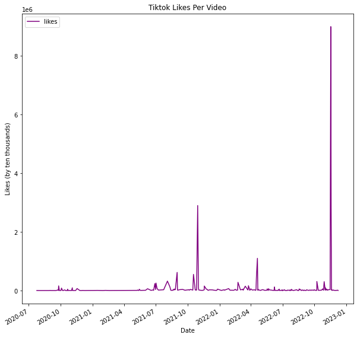

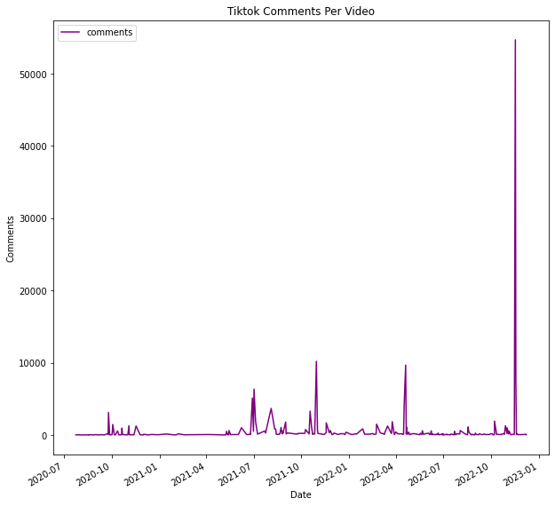

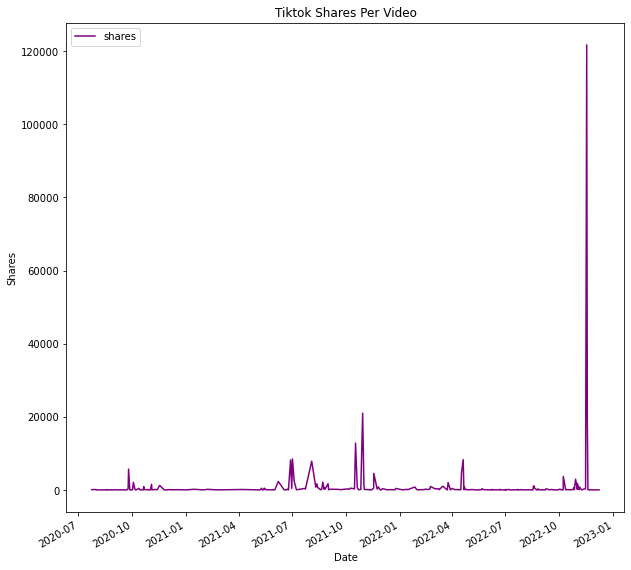

```python
# change to datetime types
tt_df['time'] = pd.to_datetime(tt_df['time'], infer_datetime_format=True)
ig_df['timestamp'] = pd.to_datetime(ig_df['timestamp'], infer_datetime_format=True)

#sort
tt_df = tt_df.sort_values(by=['time'])

tt_df.plot.line(x='time', y='likes', figsize=(10, 10), title="Tiktok Likes Per Video",
                xlabel="Date", ylabel="Likes (by ten thousands)", color="purple")
tt_df.plot.line(x='time', y='comments', figsize=(10, 10), title="Tiktok Comments Per Video",
                xlabel="Date", ylabel="Comments", color="purple")
tt_df.plot.line(x='time', y='shares', figsize=(10, 10), title="Tiktok Shares Per Video",
                xlabel="Date", ylabel="Shares", color="purple")
```

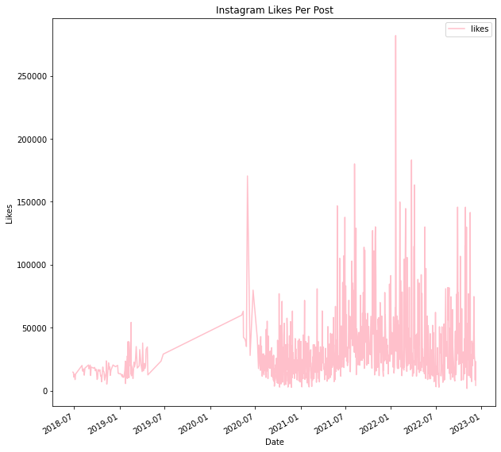

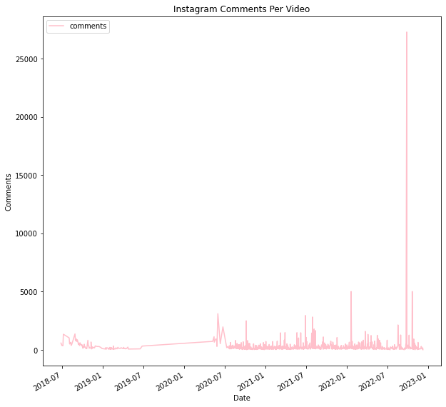

```python
ig_df = ig_df.sort_values(by=['timestamp'])

ig_df.plot.line(x='timestamp', y='likes', figsize=(10, 10), title="Instagram Likes Per Post",
                xlabel="Date", ylabel="Likes", color="pink")
ig_df.plot.line(x='timestamp', y='comments', figsize=(10, 10), title="Instagram Comments Per Video",
                xlabel="Date", ylabel="Comments", color="pink")
```

Unfortunately, these graphs don’t tell us much. It’s normal that if we display data by individual posts that the data will fluctuate pretty often. Especially considering how unpredictable social media algorithms may be. It’s clear that a particular viral post is a huge outlier in our data. So, I want to break this data up even more. I want to see how the average number of engagement per year. If this is increasing, we can possibly get a better sense of whether their social media presence is growing over the years or not.

So, I’ve added a “year” column by taking the year from the time/timestamp column. With this year column, I want to group the columns by year and for each unique year, find the average number of likes, shares, and comments. Not shown is me running tt_df[“year”].unique() to see how many unique years there were and therefore how many averages I would be computing. This time, since there were such a small number of unique years since the Bratz TikTok account has only been posting since 2020, I decided a bar graph would do the job of presenting this data.

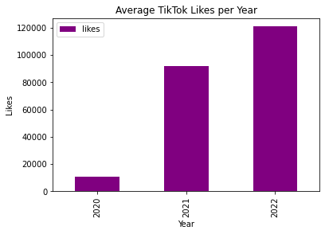

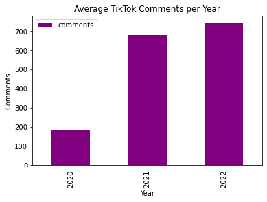

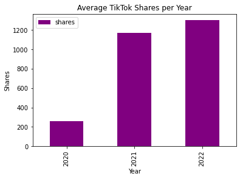

```python
tt_df['year'] = pd.DatetimeIndex(tt_df['time']).year

tt_mean = tt_df.groupby('year', as_index=False)['likes', 'comments', 'shares'].mean()

tt_mean.plot.bar(x='year', y='likes', title="Average TikTok Likes per Year",
                xlabel="Year", ylabel="Likes", color="purple")
tt_mean.plot.bar(x='year', y='comments', title="Average TikTok Comments per Year",
                xlabel="Year", ylabel="Comments", color="purple")
tt_mean.plot.bar(x='year', y='shares', title="Average TikTok Shares per Year",
                xlabel="Year", ylabel="Shares", color="purple")
```

As we can see, it seems like the TikTok engagement is increasing quite rapidly. I imagine since the comeback was first announced in 2021 (https://www.tiktok.com/@bratz/video/6978921116140178694?is_from_webapp=1&sender_device=pc&web_id=7175921701210916398), it makes sense that engagement would rise so rapidly here.

Now to repeat this process for Instagram likes/comments. The Bratz Instagram account has been posting since 2018, so we’ll have a few more averages to work with. But for the sake of consistency, I’ll present this data in a bar graph as well.

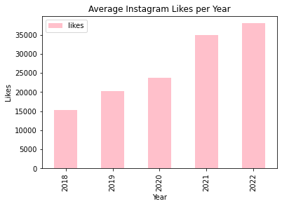

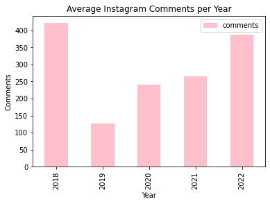

```python
ig_df['year'] = pd.DatetimeIndex(ig_df['timestamp']).year

ig_mean = ig_df.groupby('year', as_index=False)['likes', 'comments'].mean()

ig_mean.plot.bar(x='year', y='likes', title="Average Instagram Likes per Year",
                xlabel="Year", ylabel="Likes", color="pink")
ig_mean.plot.bar(x='year', y='comments', title="Average Instagram Comments per Year",
                xlabel="Year", ylabel="Comments", color="pink")
```

Now just for fun, I wanted to see which posts are the most successful on Instagram. I’ve created a new empty DataFrame for post types and created a column called “type” where I’ll store only the unique values of postType. There are only 3: Image, Sidecar, and Video. Since, I didn’t know what sidecar meant, I’ll define it super quick. It’s essentially just a album of multiple videos/images. After creating this column, I went on to create columns for both likes and comments. To fill these columns, I filtered the original dataframe for each unique post type and found the average for the number of comments and likes for each type. Not shown, is me making sure that the values were placed in the correct order by displaying the DataFrames when necessary. Since there were only three values, I decided to use a bar plot for this as well.

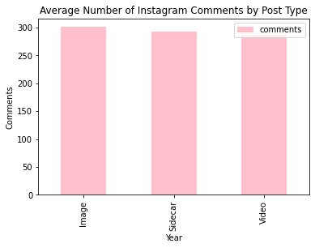

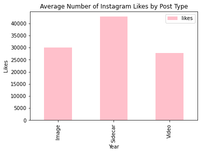

```python
post_type = pd.DataFrame()
post_type["type"] = ig_df["postType"].unique()
post_type["comments"] = [ig_df[ig_df["postType"] == "Image"]["comments"].mean(),
                         ig_df[ig_df["postType"] == "Sidecar"]["comments"].mean(),
                         ig_df[ig_df["postType"] == "Video"]["comments"].mean()]
post_type["likes"] = [ig_df[ig_df["postType"] == "Image"]["likes"].mean(),
                         ig_df[ig_df["postType"] == "Sidecar"]["likes"].mean(),
                         ig_df[ig_df["postType"] == "Video"]["likes"].mean()]
post_type.plot.bar(x='type', y='comments', title="Average Number of Instagram Comments by Post Type",
                xlabel="Year", ylabel="Comments", color="pink")
post_type.plot.bar(x='type', y='likes', title="Average Number of Instagram Likes by Post Type",
                xlabel="Year", ylabel="Likes", color="pink")
```

I guess when it comes to getting likes, sidecar posts are better. However, the comments seem to show more engagement for images.

The Bratz do a lot of collaborations as well. Typically will fashion brands or influencers. I wanted to know if a lot of their success on social media was a result of these collaborations. So, in the original DataFrame, I added a boolean column that shows whether or not another account was mentioned on a post. Then, I created another small dataFrame similar to the one in the previous dataset. First, I created a column for whether or not they collaborated with only the values True and False. Then, similar to the previous data, I filtered the original dataFrame by True and False and found the average of likes/comments for each value.

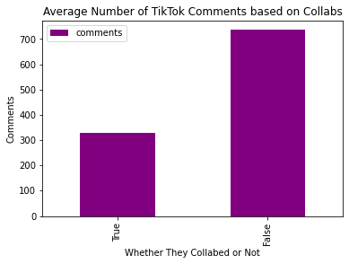

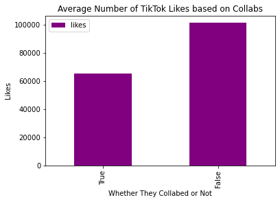

```python
tt_df["collab"] = tt_df["mention"].isnull() == False
mention_df = pd.DataFrame()
mention_df["collab"] = [True, False]
mention_df["likes"] = [tt_df[tt_df["collab"] == True]["likes"].mean(), tt_df[tt_df["collab"] == False]["likes"].mean()]
mention_df["comments"] = [tt_df[tt_df["collab"] == True]["comments"].mean(),
                          tt_df[tt_df["collab"] == False]["comments"].mean()]
mention_df.plot.bar(x='collab', y='comments', title="Average Number of TikTok Comments based on Collabs",
                xlabel="Whether They Collabed or Not", ylabel="Comments", color="purple")
mention_df.plot.bar(x='collab', y='likes', title="Average Number of TikTok Likes based on Collabs",
                xlabel="Whether They Collabed or Not", ylabel="Likes", color="purple")
```

For TikTok, it seems that the Bratz do fine all on their own. Now to repeat this process for Instagram. The only difference here is that Instagram has a system for both tagging and mentioning users. So when creating the extra column in the original Instagram DataFrame, I made the Booleans based on whether someone was tagged OR mentioned in a post.

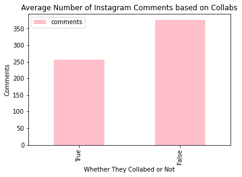

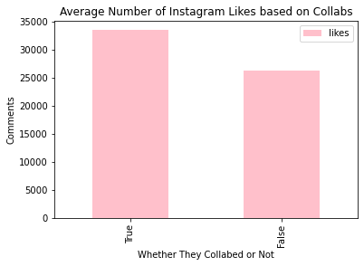

```python
ig_df["collab"] = (ig_df["tagged"].isnull() == False) | (ig_df["mentions"].isnull() == False)
tagged_df = pd.DataFrame()
tagged_df["collab"] = [True, False]
tagged_df["likes"] = [ig_df[ig_df["collab"] == True]["likes"].mean(), ig_df[ig_df["collab"] == False]["likes"].mean()]
tagged_df["comments"] = [ig_df[ig_df["collab"] == True]["comments"].mean(),
                          ig_df[ig_df["collab"] == False]["comments"].mean()]
tagged_df.plot.bar(x='collab', y='comments', title="Average Number of Instagram Comments based on Collabs",
                xlabel="Whether They Collabed or Not", ylabel="Comments", color="pink")
tagged_df.plot.bar(x='collab', y='likes', title="Average Number of Instagram Likes based on Collabs",
                xlabel="Whether They Collabed or Not", ylabel="Comments", color="pink")
```

Instagram seems like a different story! For likes, it seems more engagement comes from collaborations. This makes sense to me considering that, from what I’ve seen, there seems to be a lot of artists that revamp and redesign custom Bratz dolls on Instagram. Some examples of these accounts are @marthebratz, @monsterlool, and @engimadollz.

Okay, now I would like to get an overall prediction of how the Bratz are doing on social media. Unfortunately, it seems that grouping by year is too broad, so I decided to break it down into months. Similar to how I created the year column early, I grabbed the month from the time/timestamp column to create a column for months.

```python
tt_df['month'] = pd.DatetimeIndex(tt_df['time']).month
tt_df
```

|  | comments | time | likes | hashtag | mention | music | shares | caption | duration | year | collab | month |
| --- | --- | --- | --- | --- | --- | --- | --- | --- | --- | --- | --- | --- |
| 268 | 15 | 2020-07-24 01:38:14+00:00 | 2076 | bratz | NaN | bratz | 78 | So you think you can dance? 💕💿 #bratz #bratzd... | 11 | 2020 | False | 7 |
| 267 | 17 | 2020-07-25 18:44:39+00:00 | 1820 | bratz | NaN | bratz | 90 | Dbl tap if you can relate 💻 💕 #bratz #sopowerf... | 12 | 2020 | False | 7 |
| 266 | 26 | 2020-07-31 06:06:37+00:00 | 2345 | bratz | NaN | bratz | 123 | I’m not the jealous type 😏 #bratz #jealousyisa... | 19 | 2020 | False | 7 |
| 265 | 5 | 2020-08-01 03:28:54+00:00 | 899 | bratz | @marthebratz | bratz | 12 | Oh, hey girl 🤗#bratz #wipeitdownchallenge #hey... | 9 | 2020 | True | 8 |
| 264 | 16 | 2020-08-14 09:28:38+00:00 | 1354 | bratzdolls | NaN | bratz | 15 | Bidi bidi bomb Bratz 🎸🔥 #bratzdolls #selena #f... | 12 | 2020 | False | 8 |
| ... | ... | ... | ... | ... | ... | ... | ... | ... | ... | ... | ... | ... |
| 4 | 64 | 2022-11-30 02:42:24+00:00 | 4443 | bratz | NaN | bratz | 43 | Tag that one friend 🙄👄 #bratz #girlsniteout #g... | 10 | 2022 | False | 11 |
| 3 | 56 | 2022-12-02 21:46:54+00:00 | 5387 | bratz | @mowalolatv | mowalolatv | 38 | Bratz x @mowalolatv are almost sold out! 🛒Link... | 13 | 2022 | True | 12 |
| 2 | 102 | 2022-12-07 00:02:15+00:00 | 12700 | bratz | @Velvet | bratz | 47 | Tomorrow!! @Velvet Caviar 👄☎️ #bratz #phonecas... | 12 | 2022 | True | 12 |
| 1 | 8 | 2022-12-07 22:54:21+00:00 | 680 | bratz | @velvetcaviar | bratz | 8 | Bratz x @velvetcaviar is officially live! 📲 Li... | 29 | 2022 | True | 12 |
| 0 | 25 | 2022-12-08 01:20:24+00:00 | 1738 | bratz | @Velvet | bratz | 14 | Bratz x @Velvet Caviar is officially live! Whi... | 18 | 2022 | True | 12 |

269 rows × 12 columns

Now to make a new dataframe for average likes/comments by month. This was a bit more tedious. I broke down the original TikTok dataframe into three separate dataframes filtered by year. Then, I created an empty dataframe which I filled will the months-year. These months/years are represented by integers because in order to create a regression line, the x-axis needed numerical values. So the integers are represented by [year][month]. These integers created the date column. Next, it was onto calculating average likes/comments/shares. What I originally ended up doing was trying to manually input all this data into the columns, but thankfully I caught myself. For each year, I dedicated for loops to fill in an array for likes/comments/shares averages and add them to the array. Since some months seemed to have no activity, I filled any null values with 0.

```python
tt2020 = tt_df[tt_df["year"] == 2020]
tt2021 = tt_df[tt_df["year"] == 2021]
tt2022 = tt_df[tt_df["year"] == 2022]

tt_months = pd.DataFrame()
tt_months["date"] = [202007, 202008, 202009, 202010, 202011, 202012, 202101, 202102, 202103, 202104, 202105, 202106,
                     202107, 202108, 202109, 202110, 202111, 202112, 202201, 202202, 202203, 202204, 202205, 202206,
                     202207, 202208, 202209, 202210, 202211, 202212]
# likes
likes_avg = []
for i in range(7, 13):
    likes_avg.append(tt2020[tt2020["month"] == i]["likes"].mean())

for i in range(1, 13):
    likes_avg.append(tt2021[tt2021["month"] == i]["likes"].mean())

for i in range(1, 13):
    likes_avg.append(tt2022[tt2022["month"] == i]["likes"].mean())

tt_months["likes_avg"] = likes_avg

# comments
comments_avg = []
for i in range(7, 13):
    comments_avg.append(tt2020[tt2020["month"] == i]["comments"].mean())

for i in range(1, 13):
    comments_avg.append(tt2021[tt2021["month"] == i]["comments"].mean())

for i in range(1, 13):
    comments_avg.append(tt2022[tt2022["month"] == i]["comments"].mean())

tt_months["comments_avg"] = comments_avg

# shares
shares_avg = []
for i in range(7, 13):
    shares_avg.append(tt2020[tt2020["month"] == i]["shares"].mean())

for i in range(1, 13):
    shares_avg.append(tt2021[tt2021["month"] == i]["shares"].mean())

for i in range(1, 13):
    shares_avg.append(tt2022[tt2022["month"] == i]["shares"].mean())

tt_months["shares_avg"] = shares_avg

tt_months = tt_months.fillna(0)
tt_months
```

|  | date | likes_avg | comments_avg | shares_avg |
| --- | --- | --- | --- | --- |
| 0 | 202007 | 2080.333333 | 19.333333 | 97.000000 |
| 1 | 202008 | 1590.666667 | 17.166667 | 32.916667 |
| 2 | 202009 | 14233.000000 | 256.857143 | 464.785714 |
| 3 | 202010 | 13518.615385 | 249.615385 | 297.153846 |
| 4 | 202011 | 21829.875000 | 333.750000 | 379.875000 |
| 5 | 202012 | 3082.000000 | 52.400000 | 55.400000 |
| 6 | 202101 | 3784.500000 | 73.000000 | 103.500000 |
| 7 | 202102 | 3614.250000 | 62.000000 | 79.500000 |
| 8 | 202103 | 0.000000 | 0.000000 | 0.000000 |
| 9 | 202104 | 3929.000000 | 61.000000 | 121.000000 |
| 10 | 202105 | 11020.222222 | 156.000000 | 155.333333 |
| 11 | 202106 | 49378.750000 | 869.500000 | 1415.750000 |
| 12 | 202107 | 80340.000000 | 1828.000000 | 2309.400000 |
| 13 | 202108 | 109940.333333 | 787.166667 | 1346.500000 |
| 14 | 202109 | 20373.166667 | 193.500000 | 128.500000 |
| 15 | 202110 | 351236.363636 | 1500.181818 | 3291.181818 |
| 16 | 202111 | 44198.800000 | 409.800000 | 761.200000 |
| 17 | 202112 | 20284.333333 | 186.166667 | 163.666667 |
| 18 | 202201 | 24506.200000 | 255.200000 | 219.200000 |
| 19 | 202202 | 72002.800000 | 403.400000 | 323.800000 |
| 20 | 202203 | 52218.400000 | 469.900000 | 442.500000 |
| 21 | 202204 | 134785.000000 | 1245.615385 | 1123.461538 |
| 22 | 202205 | 26276.500000 | 193.500000 | 96.875000 |
| 23 | 202206 | 14252.380952 | 107.238095 | 41.857143 |
| 24 | 202207 | 11231.764706 | 100.294118 | 54.882353 |
| 25 | 202208 | 15422.125000 | 238.000000 | 209.250000 |
| 26 | 202209 | 12956.777778 | 85.666667 | 69.111111 |
| 27 | 202210 | 55293.764706 | 337.647059 | 611.882353 |
| 28 | 202211 | 809935.266667 | 4259.800000 | 9567.200000 |
| 29 | 202212 | 5126.250000 | 47.750000 | 26.750000 |

Now onto the long awaited regression lines. This was where numpy and matplotlib become useful. Np.polyfit gives us the slope and intercept for our data, and to actually display the line, we need to use these values in plt.plot() which is why our dates needed to be in numerical form.

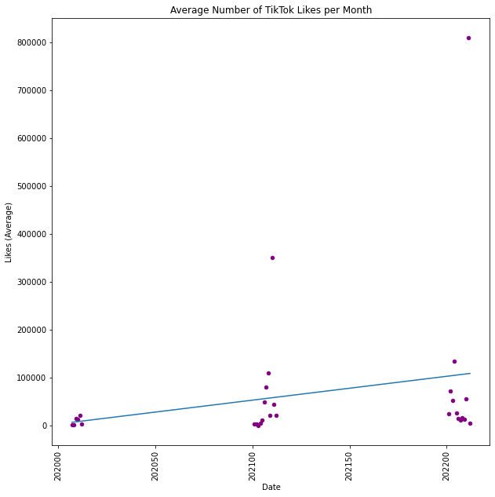

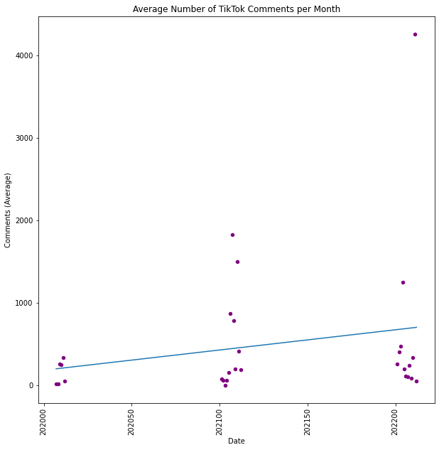

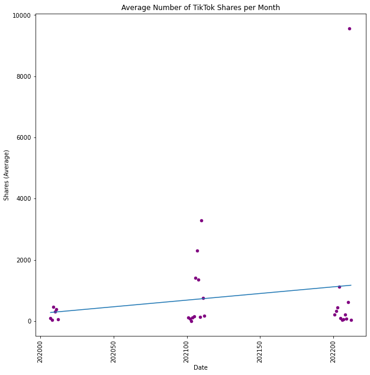

```python
tt_months.plot.scatter(x="date", y="likes_avg", figsize=(10, 10), rot=90,
                       title="Average Number of TikTok Likes per Month", xlabel="Date",
                       ylabel="Likes (Average)", color="purple")
slope, intercept = np.polyfit(tt_months['date'], tt_months['likes_avg'], 1)
plt.plot(tt_months['date'], slope * tt_months['date'] + intercept)
plt.show()

tt_months.plot.scatter(x="date", y="comments_avg", figsize=(10, 10), rot=90,
                       title="Average Number of TikTok Comments per Month", xlabel="Date",
                       ylabel="Comments (Average)", color="purple")
slope, intercept = np.polyfit(tt_months['date'], tt_months['comments_avg'], 1)
plt.plot(tt_months['date'], slope * tt_months['date'] + intercept)
plt.show()

tt_months.plot.scatter(x="date", y="shares_avg", figsize=(10, 10), rot=90,
                      title="Average Number of TikTok Shares per Month", xlabel="Date",
                       ylabel="Shares (Average)", color="purple")
slope, intercept = np.polyfit(tt_months['date'], tt_months['shares_avg'], 1)
plt.plot(tt_months['date'], slope * tt_months['date'] + intercept)
plt.show()
```

```python
ig_df['month'] = pd.DatetimeIndex(ig_df['timestamp']).month
ig_df
```

|  | caption | tagged | timestamp | postType | views | comments | firstComment | hashtag | likes | mentions | year | collab | month |
| --- | --- | --- | --- | --- | --- | --- | --- | --- | --- | --- | --- | --- | --- |
| 926 | Ethereal, divine, and a little bit dramatic. T... | NaN | 2018-06-25 22:47:49+00:00 | Image | NaN | 592 | LOOOOOOVE ANGEL 👼 ♥️ I identify a lot with Chl... | Bratz | 14691 | NaN | 2018 | False | 6 |
| 925 | Always ready to pounce on the hottest new look... | NaN | 2018-06-28 00:16:55+00:00 | Image | NaN | 495 | 😭😭😭 | Bratz | 14473 | NaN | 2018 | False | 6 |
| 924 | Her taste in clothing is as hot as her taste i... | NaN | 2018-06-29 20:10:16+00:00 | Image | NaN | 379 | NaN | Bratz | 10734 | NaN | 2018 | False | 6 |
| 923 | A fashion sense that royally rules. This is Pr... | NaN | 2018-07-02 17:00:32+00:00 | Image | NaN | 399 | I love how this is my Character and it was pos... | Bratz | 12939 | NaN | 2018 | False | 7 |
| 922 | A trail blazer on his bike and in the fashion ... | NaN | 2018-07-04 17:00:15+00:00 | Image | NaN | 356 | Cameron💖💋 | Bratz | 8755 | NaN | 2018 | False | 7 |
| ... | ... | ... | ... | ... | ... | ... | ... | ... | ... | ... | ... | ... | ... |
| 7 | Drop the ⚡️ if you would wear these to the Lim... | NaN | 2022-12-03 23:59:31+00:00 | Sidecar | NaN | 127 | @enriquehereedia tómame una foto asi | bratz | 27791 | NaN | 2022 | False | 12 |
| 6 | Me and my work bestie after our 5th iced coffe... | NaN | 2022-12-06 00:04:17+00:00 | Sidecar | NaN | 73 | She slaying in da fakin hell!! | bratz | 22604 | mowalola | 2022 | True | 12 |
| 5 | Something super fun is coming…can you guess wh... | NaN | 2022-12-06 22:26:43+00:00 | Video | 36468.0 | 79 | omg ur phone is so iconic nd pretty 😍 | bratz | 8324 | NaN | 2022 | False | 12 |
| 4 | Bratz x @velvetcaviar is officially live! 📲 Li... | NaN | 2022-12-07 22:43:18+00:00 | Video | 89971.0 | 182 | respectfully the casting was trash | bratz | 23290 | velvetcaviar | 2022 | True | 12 |
| 3 | A preekend vibe with Bratz x @mowalola Felicia... | NaN | 2022-12-09 00:24:25+00:00 | Image | NaN | 22 | Waiting for her to be available on amazon France | bratz | 4107 | mowalola | 2022 | True | 12 |

927 rows × 13 columns

```python
ig2018 = ig_df[ig_df["year"] == 2018]
ig2019 = ig_df[ig_df["year"] == 2019]
ig2020 = ig_df[ig_df["year"] == 2020]
ig2021 = ig_df[ig_df["year"] == 2021]
ig2022 = ig_df[ig_df["year"] == 2022]

ig_months = pd.DataFrame()
ig_months["date"] = [201806, 201807, 201808, 201809, 201810, 201811, 201812, 201901, 201902, 201903, 201904, 201905,
                     201906, 201907, 201908, 201909, 201910, 201911, 201912, 202001, 202002, 202003, 202004, 202005,
                     202006, 202007, 202008, 202009, 202010, 202011, 202012, 202101, 202102, 202103, 202104, 202105,
                     202106, 202107, 202108, 202109, 202110, 202111, 202112, 202201, 202202, 202203, 202204, 202205,
                     202206, 202207, 202208, 202209, 202210, 202211, 202212]

# likes
likes_avg = []
for i in range(6, 13):
    likes_avg.append(ig2018[ig2018["month"] == i]["likes"].mean())

for i in range(1, 13):
    likes_avg.append(ig2019[ig2019["month"] == i]["likes"].mean())

for i in range(1, 13):
    likes_avg.append(ig2020[ig2020["month"] == i]["likes"].mean())

for i in range(1, 13):
    likes_avg.append(ig2021[ig2021["month"] == i]["likes"].mean())

for i in range(1, 13):
    likes_avg.append(ig2022[ig2022["month"] == i]["likes"].mean())

ig_months["likes_avg"] = likes_avg

# comments
comments_avg = []
for i in range(6, 13):
    comments_avg.append(ig2018[ig2018["month"] == i]["comments"].mean())

for i in range(1, 13):
    comments_avg.append(ig2019[ig2019["month"] == i]["comments"].mean())

for i in range(1, 13):
    comments_avg.append(ig2020[ig2020["month"] == i]["comments"].mean())

for i in range(1, 13):
    comments_avg.append(ig2021[ig2021["month"] == i]["comments"].mean())

for i in range(1, 13):
    comments_avg.append(ig2022[ig2022["month"] == i]["comments"].mean())

ig_months["comments_avg"] = comments_avg


ig_months = ig_months.fillna(0)
ig_months
```

|  | date | likes_avg | comments_avg |
| --- | --- | --- | --- |
| 0 | 201806 | 13299.333333 | 488.666667 |
| 1 | 201807 | 11594.000000 | 701.666667 |
| 2 | 201808 | 17082.444444 | 741.444444 |
| 3 | 201809 | 17350.727273 | 576.818182 |
| 4 | 201810 | 13004.000000 | 276.214286 |
| 5 | 201811 | 15570.818182 | 245.727273 |
| 6 | 201812 | 16232.000000 | 181.428571 |
| 7 | 201901 | 15110.384615 | 124.923077 |
| 8 | 201902 | 20284.173913 | 106.652174 |
| 9 | 201903 | 23766.571429 | 154.142857 |
| 10 | 201904 | 23037.333333 | 140.222222 |
| 11 | 201905 | 0.000000 | 0.000000 |
| 12 | 201906 | 26199.000000 | 212.000000 |
| 13 | 201907 | 0.000000 | 0.000000 |
| 14 | 201908 | 0.000000 | 0.000000 |
| 15 | 201909 | 0.000000 | 0.000000 |
| 16 | 201910 | 0.000000 | 0.000000 |
| 17 | 201911 | 0.000000 | 0.000000 |
| 18 | 201912 | 0.000000 | 0.000000 |
| 19 | 202001 | 0.000000 | 0.000000 |
| 20 | 202002 | 0.000000 | 0.000000 |
| 21 | 202003 | 0.000000 | 0.000000 |
| 22 | 202004 | 0.000000 | 0.000000 |
| 23 | 202005 | 64116.000000 | 1112.142857 |
| 24 | 202006 | 53885.500000 | 1258.000000 |
| 25 | 202007 | 26730.294118 | 210.470588 |
| 26 | 202008 | 24567.588235 | 257.352941 |
| 27 | 202009 | 16702.138889 | 181.361111 |
| 28 | 202010 | 23218.785714 | 238.214286 |
| 29 | 202011 | 22409.527778 | 151.472222 |
| 30 | 202012 | 20890.055556 | 161.194444 |
| 31 | 202101 | 22099.032258 | 186.903226 |
| 32 | 202102 | 20132.125000 | 192.906250 |
| 33 | 202103 | 26293.000000 | 285.156250 |
| 34 | 202104 | 20686.161290 | 170.096774 |
| 35 | 202105 | 30114.432432 | 237.945946 |
| 36 | 202106 | 40164.125000 | 332.875000 |
| 37 | 202107 | 44590.416667 | 419.333333 |
| 38 | 202108 | 47720.750000 | 365.708333 |
| 39 | 202109 | 49252.500000 | 298.750000 |
| 40 | 202110 | 55078.041667 | 320.000000 |
| 41 | 202111 | 38867.160000 | 212.320000 |
| 42 | 202112 | 37140.625000 | 204.125000 |
| 43 | 202201 | 48518.100000 | 489.800000 |
| 44 | 202202 | 46941.571429 | 259.952381 |
| 45 | 202203 | 40187.214286 | 298.821429 |
| 46 | 202204 | 43308.875000 | 340.750000 |
| 47 | 202205 | 38693.913043 | 308.652174 |
| 48 | 202206 | 26531.304348 | 154.652174 |
| 49 | 202207 | 21735.818182 | 160.136364 |
| 50 | 202208 | 38406.473684 | 366.684211 |
| 51 | 202209 | 42084.826087 | 1368.695652 |
| 52 | 202210 | 38898.888889 | 442.814815 |
| 53 | 202211 | 35857.125000 | 162.916667 |
| 54 | 202212 | 29894.857143 | 137.285714 |

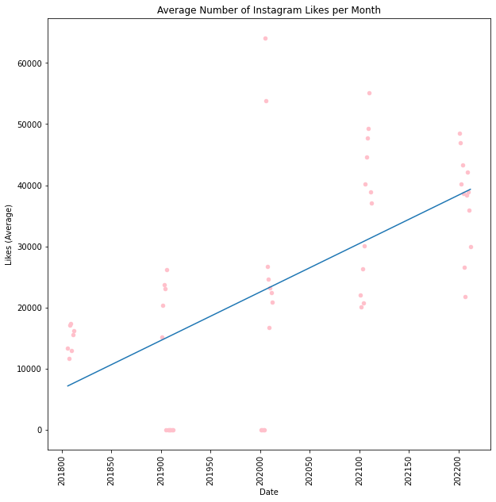

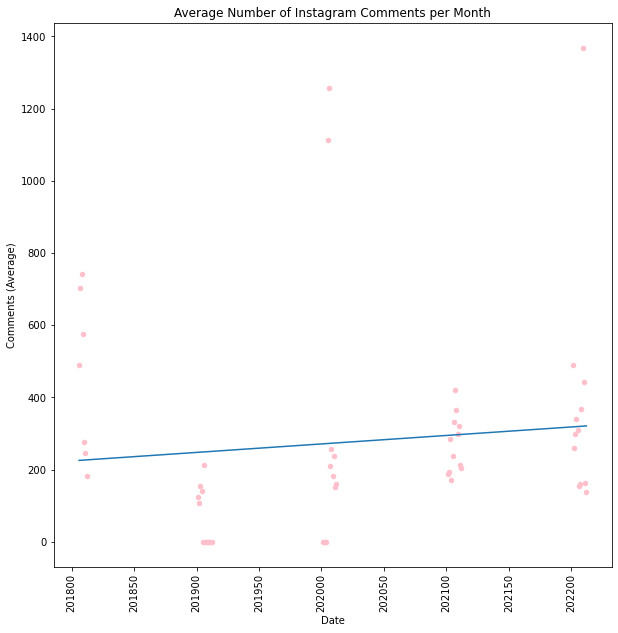

```python
ig_months.plot.scatter(x="date", y="likes_avg", figsize=(10, 10), rot=90,
                       title="Average Number of Instagram Likes per Month", xlabel="Date",
                       ylabel="Likes (Average)", color="pink")
slope, intercept = np.polyfit(ig_months['date'], ig_months['likes_avg'], 1)
plt.plot(ig_months['date'], slope * ig_months['date'] + intercept)
plt.show()

ig_months.plot.scatter(x="date", y="comments_avg", figsize=(10, 10), rot=90,
                       title="Average Number of Instagram Comments per Month", xlabel="Date",
                       ylabel="Comments (Average)", color="pink")
slope, intercept = np.polyfit(ig_months['date'], ig_months['comments_avg'], 1)
plt.plot(ig_months['date'], slope * ig_months['date'] + intercept)
plt.show()
```

And Instagram engagement is increasing quite rapidly! This is great! Overall, I would say that from all this data we can conclude that the Bratz are on the road to a successful comeback! They’ve obviously got a strong social media presence to promote new products and projects!